# Analisis Exploratorio

Gianfranco Giovannini Villalobos y Fiorella Fernandez Calderon

2023-11-27

[figure not shown]

1

[figure not shown]

2

[figure not shown]

3

# Analitica descriptiva

En esta seccion vamos a explorar la distribuccion y las variables que nos causaron mayor interes de este dataset.

```
##
##  DESCRIPTIVES
##
##  Descriptives
##  ──────────────────
##               sex
##  ──────────────────
##    N          303
##    Missing      0
##  ──────────────────
```

```
## Frequencies
## Cleveland$sex
## Type: Character
##
##                Freq   % Valid   % Valid Cum.   % Total   % Total Cum.
## ------------ ------ --------- -------------- --------- --------------
##         Male    206     67.99          67.99     67.99          67.99
##       Female     97     32.01         100.00     32.01         100.00
##         <NA>      0                               0.00         100.00
##        Total    303    100.00         100.00    100.00         100.00
```

En este dataset los hombres superan en numero a las mujeres por un poco mas del doble. Los hombres representan 68% de los datos y las mujeres un 32%.

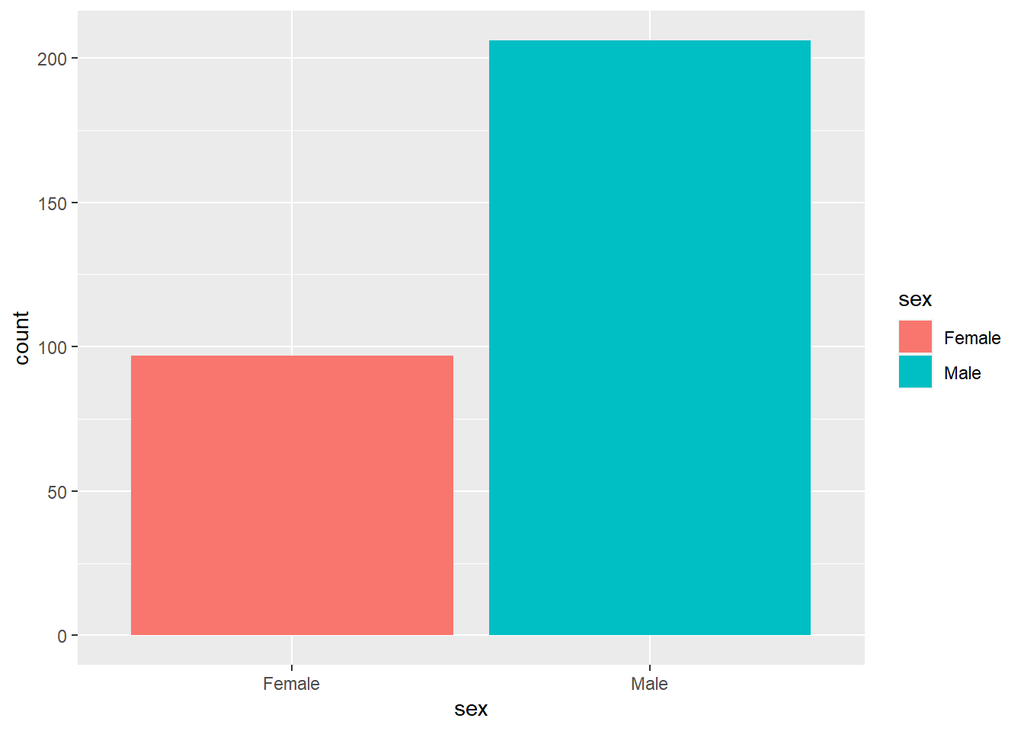

```
##
##  DESCRIPTIVES
##
##  Descriptives
##  ──────────────────
##               cp
##  ──────────────────
##    N          303
##    Missing      0
##  ──────────────────
```

```
## Frequencies
## Cleveland$cp
## Type: Character
##
##                          Freq   % Valid   % Valid Cum.   % Total   % Total Cum.
## ---------------------- ------ --------- -------------- --------- --------------
##           asymptomatic    144     47.52          47.52     47.52          47.52
##       non-anginal pain     86     28.38          75.91     28.38          75.91
##        atypical angina     50     16.50          92.41     16.50          92.41
##         typical angina     23      7.59         100.00      7.59         100.00
##                   <NA>      0                               0.00         100.00
##                  Total    303    100.00         100.00    100.00         100.00
```

El dolor de pecho asintomatico es la categoria mas comun, seguida de dolor no angino, angina atipica y angina tipica como la menos comun.

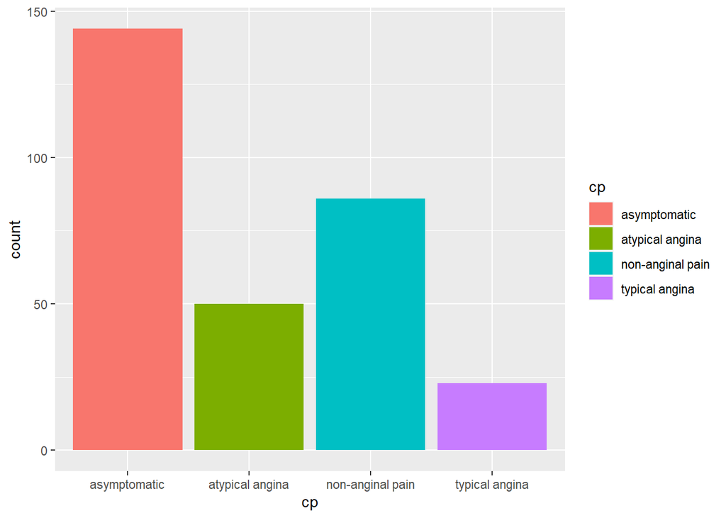

```
##
##  DESCRIPTIVES
##
##  Descriptives
##  ────────────────────────────────────────────────────────────────────
##                           cp                  sex       age
##  ────────────────────────────────────────────────────────────────────
##    N                      asymptomatic        Female             40
##                                               Male              104
##                           atypical angina     Female             18
##                                               Male               32
##                           non-anginal pain    Female             35
##                                               Male               51
##                           typical angina      Female              4
##                                               Male               19
##    Mean                   asymptomatic        Female       57.32500
##                                               Male         55.10577
##                           atypical angina     Female       51.94444
##                                               Male         51.03125
##                           non-anginal pain    Female       54.97143
##                                               Male         52.82353
##                           typical angina      Female       63.25000
##                                               Male         54.31579
##    Median                 asymptomatic        Female       58.50000
##                                               Male         57.00000
##                           atypical angina     Female       52.00000
##                                               Male         52.00000
##                           non-anginal pain    Female             54
##                                               Male               52
##                           typical angina      Female       63.00000
##                                               Male               59
##    Mode                   asymptomatic        Female       62.00000
##                                               Male         57.00000
##                           atypical angina     Female       41.00000
##                                               Male         41.00000
##                           non-anginal pain    Female       54.00000
##                                               Male         51.00000
##                           typical angina      Female       58.00000
##                                               Male         59.00000
##    Standard deviation     asymptomatic        Female       7.529046
```

[output cut: 41 more lines]

```
##                           atypical angina     Female    0.005812802
##                                               Male       0.05204542
##                           non-anginal pain    Female     -0.9732314
##                                               Male       -0.6494152
##                           typical angina      Female      -3.720635
##                                               Male       -0.6987383
##    Std. error kurtosis    asymptomatic        Female      0.7326003
##                                               Male        0.4694546
##                           atypical angina     Female       1.037795
##                                               Male        0.8093713
##                           non-anginal pain    Female      0.7777944
##                                               Male        0.6559204
##                           typical angina      Female       2.618615
##                                               Male         1.014270
##  ────────────────────────────────────────────────────────────────────
```

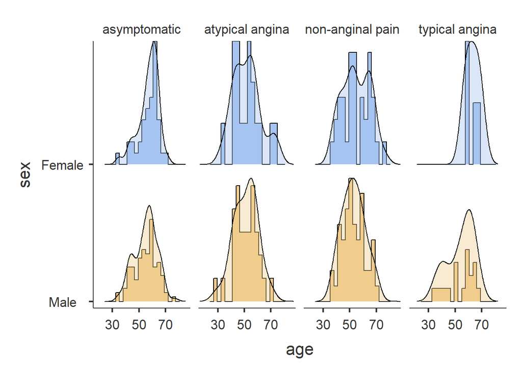

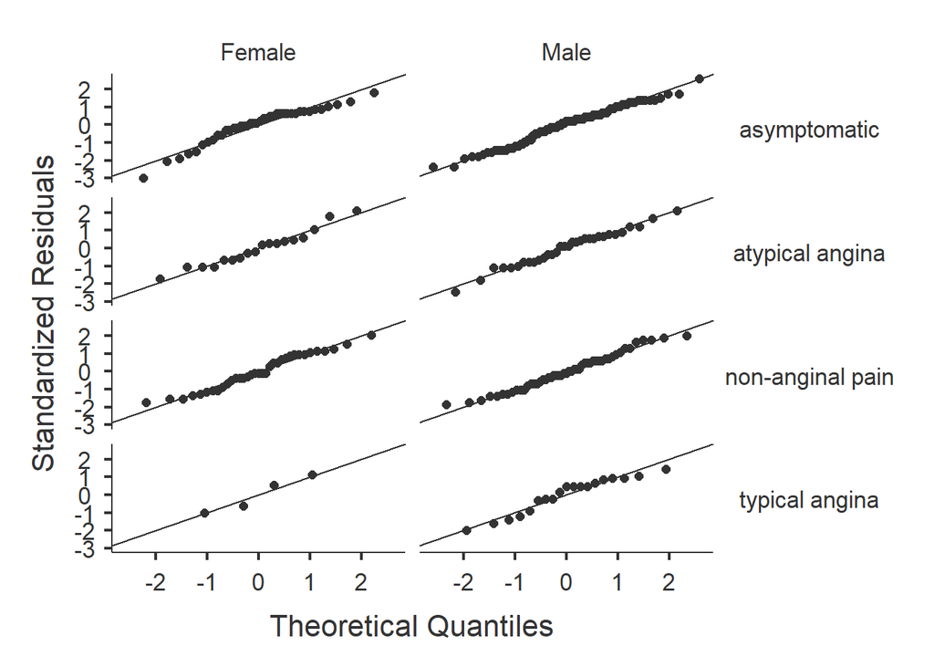

En términos generales, podemos observar que las mujeres de la muestra tenían una edad promedio de 55.7 y los hombres una edad promedio de 53.8.

El rango de edades de los pacientes en la muestra va desde 29 hasta los 77 años para los hombres y las mujeres de 34 a 76 años.

Un hecho que se puede observar a simple vista es como la mayoría de los pacientes asintomáticos presentan una edad promedio de 55.1 años para hombres y 57.3 para mujeres. En cuanto a la angina atípica, el promedio de edad entre hombres y mujeres es bastante similar dentro de los 51 años. Para la angina típica se observa una diferencia de edad más marcada entre los sexos, donde los hombres tienen un promedio de edad de 54.3 y las mujeres de 63.3 -casi 10 años de diferencia entre las edades promedio del grupo de pacientes afectado por este padecimiento cardíaco-. Lo mismo para el dolor de pecho no relacionado con angina, en esta categoría los hombres tienen un promedio de edad de 52.8 y las mujeres de 55 años.

Algo que llama mucho la atención en primera instancia del hsitograma es como en la categoría de angina típica se puede observar como el paciente más joven en el grupo masculino tiene una de edad de 34, siendo esto un outlier, mientras que el paciente mas joven en el grupo femenino tiene una de edad de 58. Igualmente, es llamativa la kurtosis promedio que presentan los hombres, siendo negativa en la mayoría de las categorías; siendo la angina atípica, en hombres, la que tiene una kurtosis más cercana a la normal. Estos resultados en la kurtosis nos permiten entender que las anginas típicas y dolores de pecho se presentan en rangos de edades más amplios para los hombres que para las mujeres.

En cuanto a los graficos de QQ la categoria de hombres con un dolor en el pecho de caracter asintomatico es la categoria que presenta lo mas cercano a una distribuccion normal.

```
##
##  DESCRIPTIVES
##
##  Descriptives
##  ───────────────────────────────────────────────────────────────────
##                           sex       cp                  trestbps
##  ───────────────────────────────────────────────────────────────────
##    N                      Female    asymptomatic                40
##                                     atypical angina             18
##                                     non-anginal pain            35
##                                     typical angina               4
##                           Male      asymptomatic               104
##                                     atypical angina             32
##                                     non-anginal pain            51
##                                     typical angina              19
##    Mean                   Female    asymptomatic          139.0750
##                                     atypical angina       128.0556
##                                     non-anginal pain      127.8857
##                                     typical angina        147.5000
##                           Male      asymptomatic          129.5577
##                                     atypical angina       128.5938
##                                     non-anginal pain      131.9412
##                                     typical angina        139.4737
##    Median                 Female    asymptomatic          138.0000
##                                     atypical angina       130.0000
##                                     non-anginal pain           128
##                                     typical angina        150.0000
##                           Male      asymptomatic          128.0000
##                                     atypical angina       126.5000
##                                     non-anginal pain           130
##                                     typical angina             138
##    Mode                   Female    asymptomatic          130.0000
##                                     atypical angina       130.0000
##                                     non-anginal pain      120.0000
##                                     typical angina        150.0000
##                           Male      asymptomatic          140.0000
##                                     atypical angina       120.0000
##                                     non-anginal pain      130.0000
##                                     typical angina        110.0000
##    Standard deviation     Female    asymptomatic          22.78257
```

[output cut: 57 more lines]

```
##                                     non-anginal pain     0.9739594
##                                     typical angina       0.6297763
##                           Male      asymptomatic         0.9738116
##                                     atypical angina      0.8269473
##                                     non-anginal pain     0.9706529
##                                     typical angina       0.9443008
##    Shapiro-Wilk p         Female    asymptomatic         0.0870531
##                                     atypical angina      0.3585831
##                                     non-anginal pain     0.5606880
##                                     typical angina       0.0012407
##                           Male      asymptomatic         0.0369518
##                                     atypical angina      0.0001366
##                                     non-anginal pain     0.2353682
##                                     typical angina       0.3146920
##  ───────────────────────────────────────────────────────────────────
```

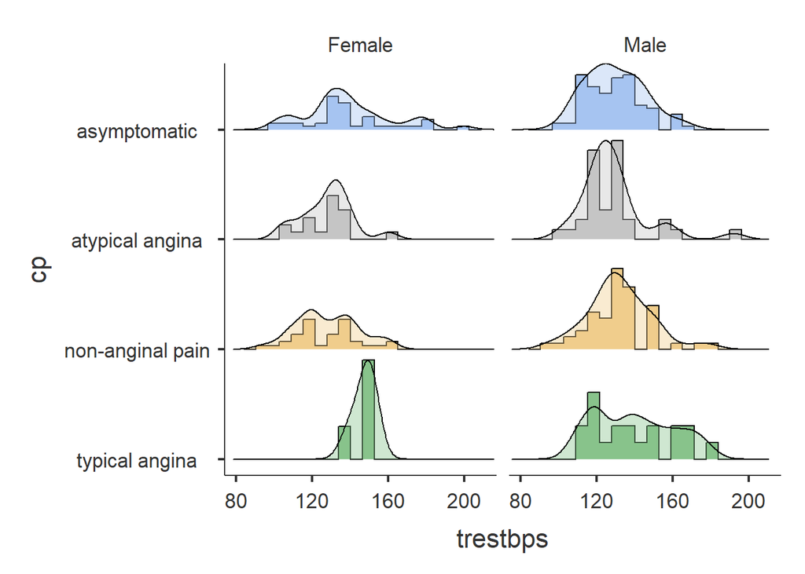

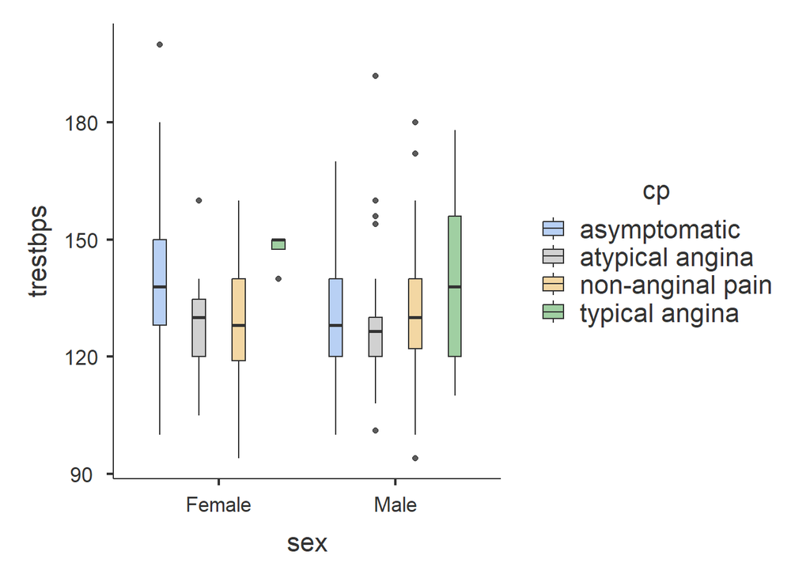

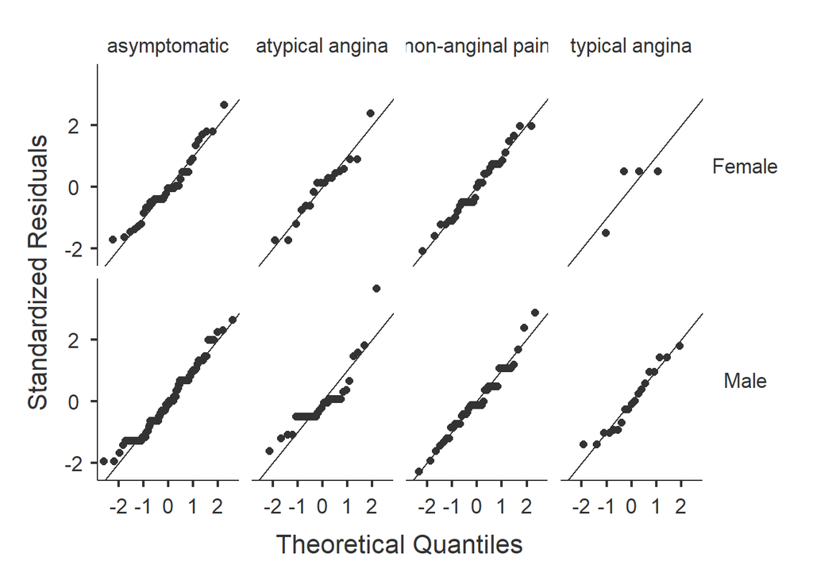

En cuanto a promedios podemos observar en grupo femenino el promedio mas alto de presion arterial en la categoria angina tipica con un total de 148 mm hg mientras que las demas categorias presenta promedios de 128 y 139 en el caso de los hombres sus promedios se mantiene en un rango bastante cercano de 129 a 139 siendo la categoria angina tipica la mas alta con un total de 139 mm hg dandonos a entender que en promedio los pacientes con una angina tipica tienden en promedio a tener una presion arterial en reposo mas alta.

Analizando los histogramas de las presiones arteriales en reposo, podemos observar que tanto para hombres como para mujeres la mayoría de categorías presentan kurtosis lejanas al promedio, sea positiva o negativa; siendo el grupo de mujeres asintomáticas las que presentan una presión más cercana a una kurtosis normal.

En el grupo de mujeres las categorias de angina atipica y dolor no anginal presentan un desplazamiento que se asemeja mas a la de una distribuccion normal mientras que las otras categorias como asintomatico presentan un desplazamiento positivo muy cercano a 1 y la categoria angina tipica presenta un desplazamiento negativo significativo de -2. Similarmente, en el grupo de hombres todas las categorias tiene un desplazamiento que se puede considerar normal a excepcion de la categoria angina tipica la cual tiene un desplazamiento positivo de 1.85.

Una observacion relevante es como la presion arterial en la categoria asintomatico del grupo femenino presenta una distribucion mas amplia que el grupo masculino, caso contrario se da en las demas categorias donde el grupo masculino tiene una distribucion mas amplia.

Observando los graficos de caja en la categoria asintomatico del grupo femenino podemos encontrar un paciente con la presion arterial mas alta con un total de 200 mm hg lo cual podria verse como un outlier significativo lo cual explicaria porque la distribuccion femenina es mas amplia que la masculina en esta categoria. Por otra parte se puede observar como en el grupo de hombres en las categorias de angina atipica y dolor no anguinal se encuentran numerosos outliers con presion alta y baja en relacion a la mayoria de sus datos por categoria. En terminos generales los outliers amplian la distribuccion al mismo tiempo manteniendo una kurtosis positiva.

```
##
##  DESCRIPTIVES
##
##  Descriptives
##  ───────────────────────────────────────────────────────────────────
##                           sex       cp                  chol
##  ───────────────────────────────────────────────────────────────────
##    N                      Female    asymptomatic                40
##                                     atypical angina             18
##                                     non-anginal pain            35
##                                     typical angina               4
##                           Male      asymptomatic               104
##                                     atypical angina             32
##                                     non-anginal pain            51
##                                     typical angina              19
##    Mean                   Female    asymptomatic          268.4750
##                                     atypical angina       251.4444
##                                     non-anginal pain      261.0571
##                                     typical angina        247.0000
##                           Male      asymptomatic          243.6058
##                                     atypical angina       241.0312
##                                     non-anginal pain      232.2353
##                                     typical angina        235.0526
##    Median                 Female    asymptomatic          261.0000
##                                     atypical angina       247.0000
##                                     non-anginal pain           256
##                                     typical angina        239.5000
##                           Male      asymptomatic          244.5000
##                                     atypical angina       235.5000
##                                     non-anginal pain           232
##                                     typical angina             233
##    Mode                   Female    asymptomatic          197.0000
##                                     atypical angina       204.0000
##                                     non-anginal pain      141.0000
##                                     typical angina        226.0000
##                           Male      asymptomatic          177.0000
##                                     atypical angina       220.0000
##                                     non-anginal pain      175.0000
##                                     typical angina        234.0000
##    Standard deviation     Female    asymptomatic          61.68655
```

[output cut: 57 more lines]

```
##                                     non-anginal pain     0.8515848
##                                     typical angina       0.8365768
##                           Male      asymptomatic         0.9891386
##                                     atypical angina      0.9736177
##                                     non-anginal pain     0.9743835
##                                     typical angina       0.9507770
##    Shapiro-Wilk p         Female    asymptomatic         0.3981062
##                                     atypical angina      0.8082862
##                                     non-anginal pain     0.0002505
##                                     typical angina       0.1856071
##                           Male      asymptomatic         0.5672484
##                                     atypical angina      0.6045959
##                                     non-anginal pain     0.3332358
##                                     typical angina       0.4073697
##  ───────────────────────────────────────────────────────────────────
```

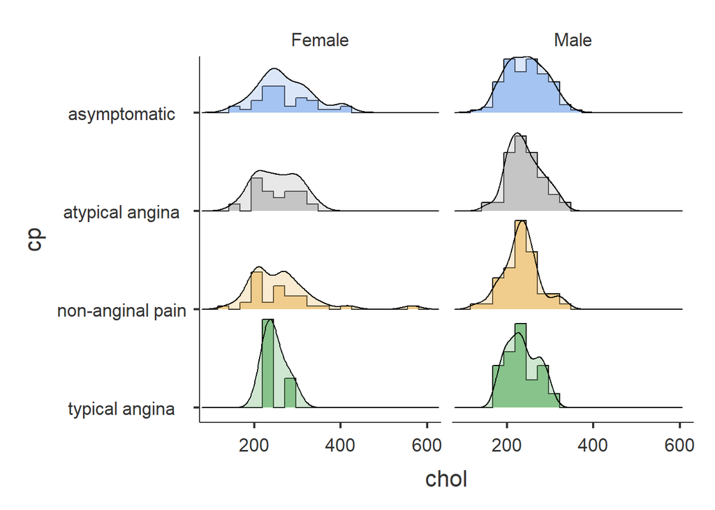

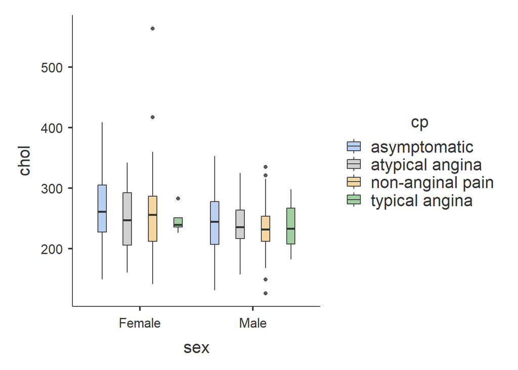

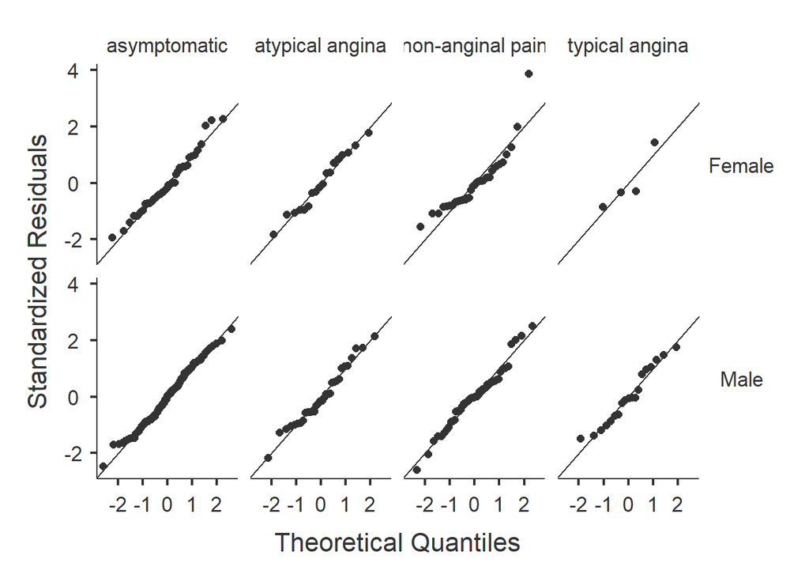

En promedio las mujeres presentan un nivel mas alto de colesterol.

observando el grafico de vemos que debido a un outlier en la categoria de dolor no anginal en el grupo femenino podemos ver que amplia o desplaza el data set considerablemente como tal se puede ver que en esta categoria presentamos dos individuos con un muy alto nivel de colesterol con 564. Este mismo escenarion se da en la categoria dolor no anginal en hombres donde el desplazamiento no es tan pronunciado y en esta categoria se encuentra el individuo con el colesterol mas bajo con 126.

```
##
##  DESCRIPTIVES
##
##  Descriptives
##  ───────────────────────────────────────────────────────────────────
##                           cp                  sex       thalach
##  ───────────────────────────────────────────────────────────────────
##    N                      asymptomatic        Female            40
##                                               Male             104
##                           atypical angina     Female            18
##                                               Male              32
##                           non-anginal pain    Female            35
##                                               Male              51
##                           typical angina      Female             4
##                                               Male              19
##    Mean                   asymptomatic        Female      145.6750
##                                               Male        138.7596
##                           atypical angina     Female      162.8333
##                                               Male        162.1875
##                           non-anginal pain    Female      151.8000
##                                               Male        157.8824
##                           typical angina      Female      149.5000
##                                               Male        157.3158
##    Median                 asymptomatic        Female      148.0000
##                                               Male        140.5000
##                           atypical angina     Female      162.5000
##                                               Male        164.0000
##                           non-anginal pain    Female           158
##                                               Male             157
##                           typical angina      Female      156.5000
##                                               Male             159
##    Mode                   asymptomatic        Female      122.0000
##                                               Male        132.0000
##                           atypical angina     Female      162.0000
##                                               Male        156.0000
##                           non-anginal pain    Female      172.0000
##                                               Male        150.0000
##                           typical angina      Female      114.0000
##                                               Male        178.0000
##    Standard deviation     asymptomatic        Female      17.62776
```

[output cut: 57 more lines]

```
##                           atypical angina     Female     0.9248433
##                                               Male       0.9638961
##                           non-anginal pain    Female     0.8726117
##                                               Male       0.9860938
##                           typical angina      Female     0.8938377
##                                               Male       0.9396655
##    Shapiro-Wilk p         asymptomatic        Female     0.2814143
##                                               Male       0.4875123
##                           atypical angina     Female     0.1574881
##                                               Male       0.3497515
##                           non-anginal pain    Female     0.0007854
##                                               Male       0.8087634
##                           typical angina      Female     0.4010992
##                                               Male       0.2600593
##  ───────────────────────────────────────────────────────────────────
```

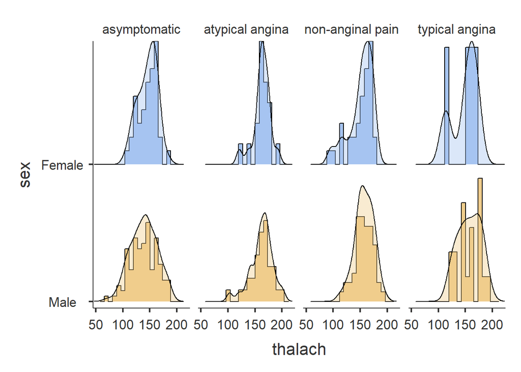

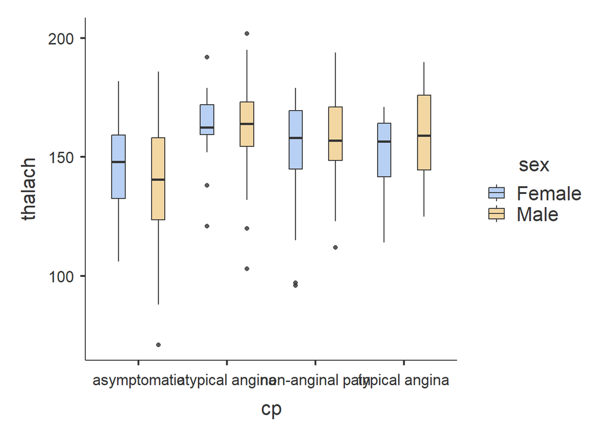

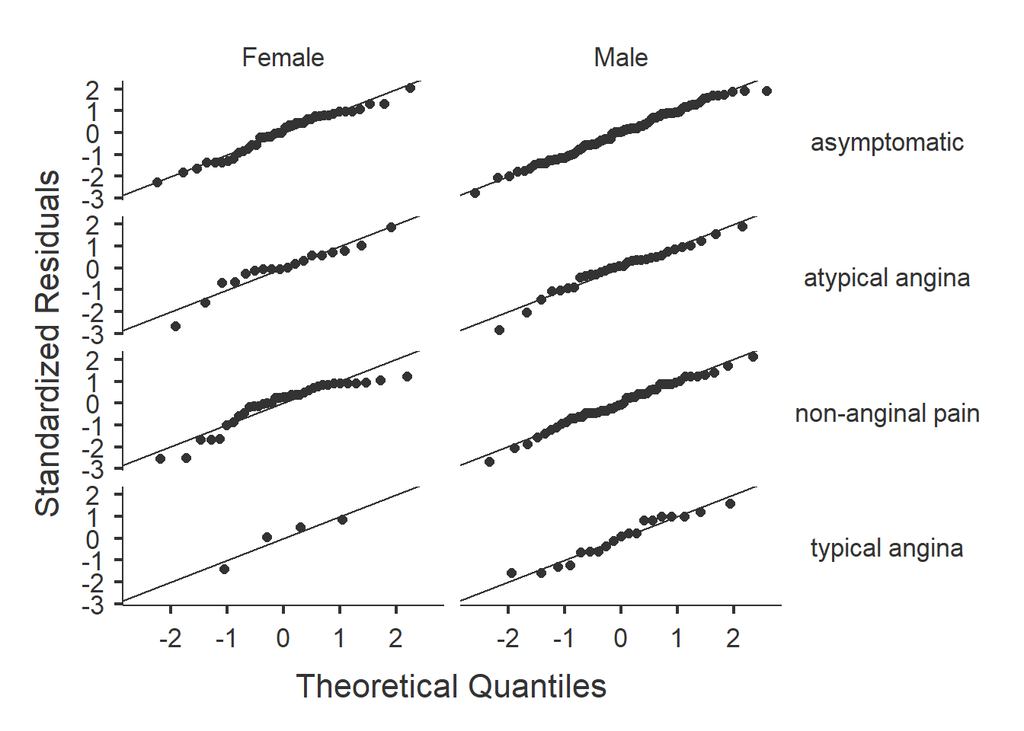

La categoria con el ritmo cardiaco mas alto es angina atipica con un ritmo cardiaco de 163 para mujeres y 162 para hombres. Seguido de las categorias angina tipica y dolor no anginal las cuales presentan promedios muy similares con un rango 150-158 y la categoria asintomatico tiene los promedios mas bajos para hombres y mujeres con 139 y 146 respectivamente.

Según el histograma presentado, podemos observar un desplazamiento negativo -hacia la derecha-; esto lo confirman los datos del skewness donde se muestran todos los datos negativos en todas las categorías, tanto para hombres como para mujeres.

En cuanto a la kurtosis, la única cercana a una distribución normal es la que presenta el dolor no anginal en hombres. Demostrando anormalidad en la distribución de todas las demás categorías, para hombres y mujeres.

Como lo mencionamos anteriormente, esta ausencia de normalidad puede deberse, en algunas de las categorías, a los outliers presentes en los datos.

Observando el grafico de cajas podemos notar que a pesar de la categoria asintomatica del grupo hombres tener una distribuccion de las mas cercanas a normal el outlier del individuo con 71 latidos por minuto esta afectando la normalidad de la distribuccion. La categoria angina atipica presenta varios outliers en ambos grupos en esta categoria tambien se encuentra el paciente con el mayor numero de latidos con un total de 202 al igual que la categoria de dolor no anginal la cual presenta outliers en sus rangos mas bajos.

Como lo mencionamos anteriormente, esta ausencia de normalidad puede deberse, en algunas de las categorías, a los outliers presentes en los datos. La unica categoria la cual presental lo mas cercano a normalidad es la categoria de dolor no angino basado en Shapiro-Wilk y demas pruebas.

# Otras variables

En esta seccion mostramos otras variables del dataset que desafortunadamente no fueron de mucha relevancia para nuestro analisis pero que de igual forma merecen ser observadas e illustradas.

```
##
##  DESCRIPTIVES
##
##  Descriptives
##  ─────────────────────────────────────────────────
##               sex       cp                  thal
##  ─────────────────────────────────────────────────
##    N          Female    asymptomatic          40
##                         atypical angina       18
##                         non-anginal pain      35
##                         typical angina         4
##               Male      asymptomatic         104
##                         atypical angina       32
##                         non-anginal pain      51
##                         typical angina        19
##    Missing    Female    asymptomatic           0
##                         atypical angina        0
##                         non-anginal pain       0
##                         typical angina         0
##               Male      asymptomatic           0
##                         atypical angina        0
##                         non-anginal pain       0
##                         typical angina         0
##  ─────────────────────────────────────────────────
```

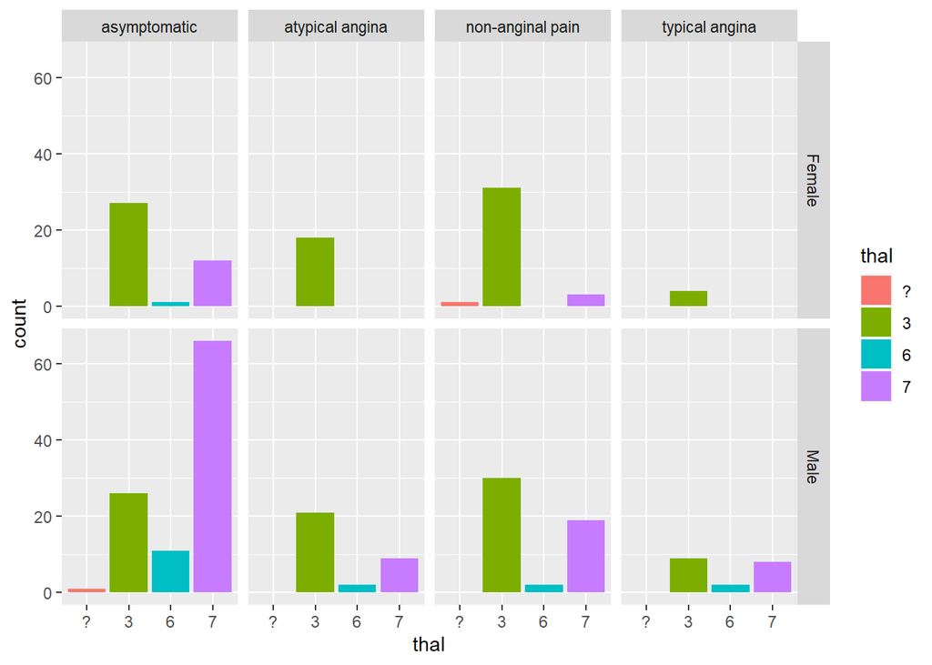

```
##
##  DESCRIPTIVES
##
##  Descriptives
##  ───────────────────────────────────────────────────────────────────
##                           sex       cp                  fbs
##  ───────────────────────────────────────────────────────────────────
##    N                      Female    asymptomatic                40
##                                     atypical angina             18
##                                     non-anginal pain            35
##                                     typical angina               4
##                           Male      asymptomatic               104
##                                     atypical angina             32
##                                     non-anginal pain            51
##                                     typical angina              19
##    Mean                   Female    asymptomatic         0.1250000
##                                     atypical angina      0.1111111
##                                     non-anginal pain     0.1142857
##                                     typical angina       0.2500000
##                           Male      asymptomatic         0.1250000
##                                     atypical angina     0.09375000
##                                     non-anginal pain     0.2549020
##                                     typical angina       0.2105263
##    Median                 Female    asymptomatic          0.000000
##                                     atypical angina       0.000000
##                                     non-anginal pain             0
##                                     typical angina        0.000000
##                           Male      asymptomatic          0.000000
##                                     atypical angina       0.000000
##                                     non-anginal pain             0
##                                     typical angina               0
##    Mode                   Female    asymptomatic          0.000000
##                                     atypical angina       0.000000
##                                     non-anginal pain      0.000000
##                                     typical angina        0.000000
##                           Male      asymptomatic          0.000000
##                                     atypical angina       0.000000
##                                     non-anginal pain      0.000000
##                                     typical angina        0.000000
##    Standard deviation     Female    asymptomatic         0.3349321
```

[output cut: 49 more lines]

```
##                                     non-anginal pain      4.689333
##                                     typical angina        4.000000
##                           Male      asymptomatic          3.359348
##                                     atypical angina       6.998652
##                                     non-anginal pain    -0.6847476
##                                     typical angina       0.4191176
##    Std. error kurtosis    Female    asymptomatic         0.7326003
##                                     atypical angina       1.037795
##                                     non-anginal pain     0.7777944
##                                     typical angina        2.618615
##                           Male      asymptomatic         0.4694546
##                                     atypical angina      0.8093713
##                                     non-anginal pain     0.6559204
##                                     typical angina        1.014270
##  ───────────────────────────────────────────────────────────────────
```

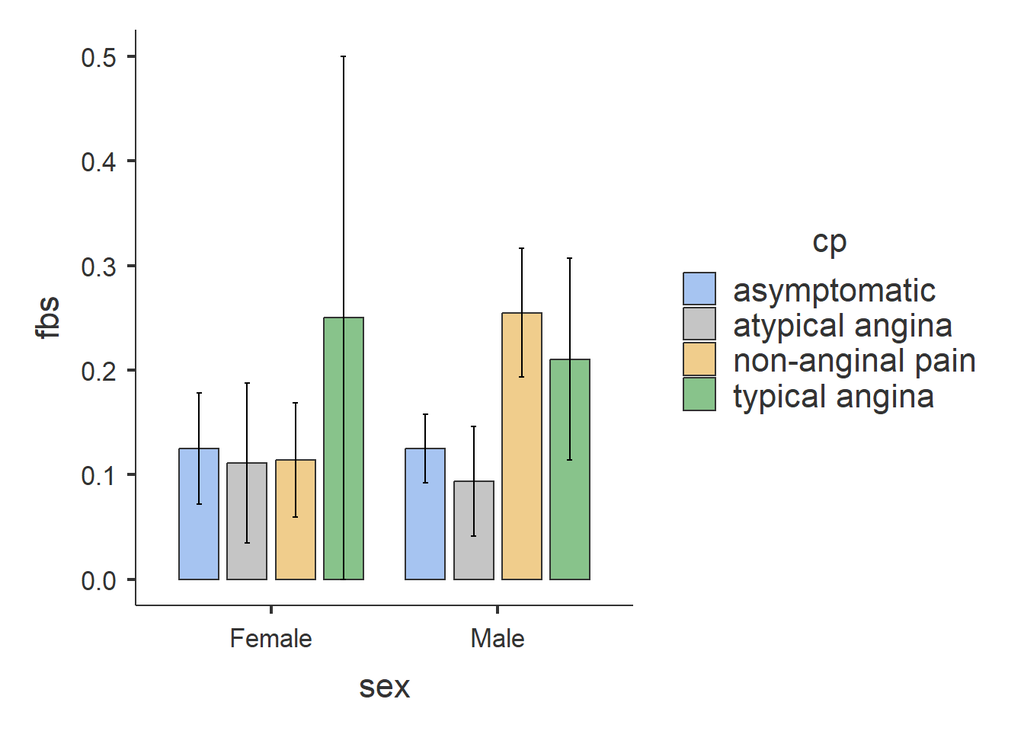

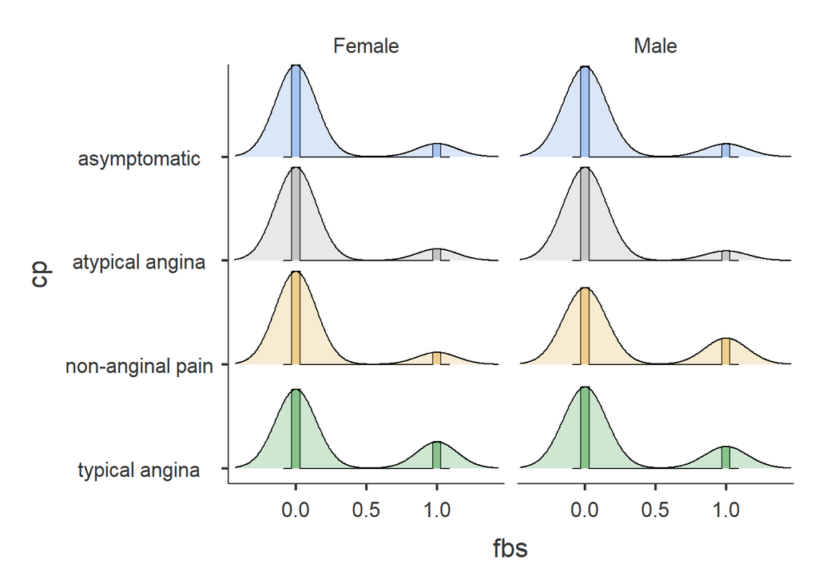

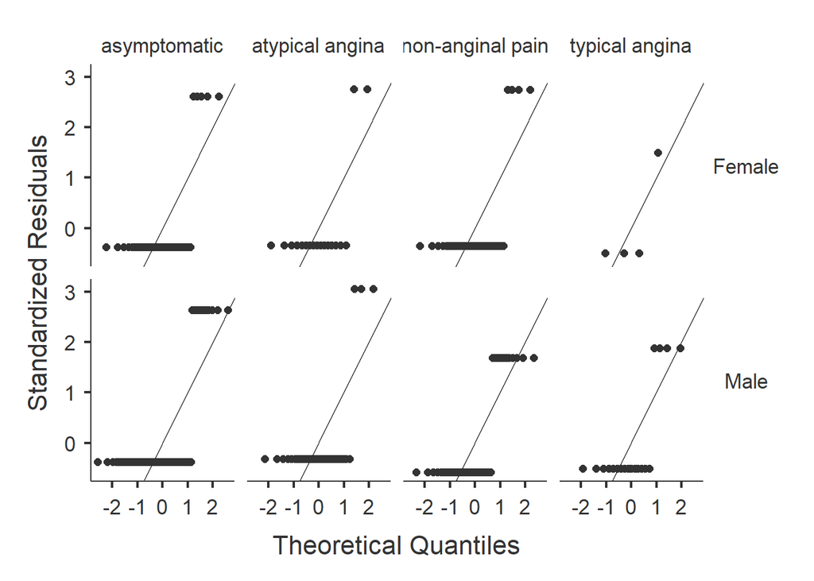

```
##
##  DESCRIPTIVES
##
##  Descriptives
##  ───────────────────────────────────────────────────────────────────
##                           sex       cp                  restecg
##  ───────────────────────────────────────────────────────────────────
##    N                      Female    asymptomatic                40
##                                     atypical angina             18
##                                     non-anginal pain            35
##                                     typical angina               4
##                           Male      asymptomatic               104
##                                     atypical angina             32
##                                     non-anginal pain            51
##                                     typical angina              19
##    Mean                   Female    asymptomatic          1.100000
##                                     atypical angina      0.8888889
##                                     non-anginal pain     0.8857143
##                                     typical angina       0.5000000
##                           Male      asymptomatic          1.125000
##                                     atypical angina      0.6875000
##                                     non-anginal pain     0.8235294
##                                     typical angina        1.368421
##    Median                 Female    asymptomatic          2.000000
##                                     atypical angina       0.000000
##                                     non-anginal pain             0
##                                     typical angina        0.000000
##                           Male      asymptomatic          2.000000
##                                     atypical angina       0.000000
##                                     non-anginal pain             0
##                                     typical angina               2
##    Mode                   Female    asymptomatic          2.000000
##                                     atypical angina       0.000000
##                                     non-anginal pain      0.000000
##                                     typical angina        0.000000
##                           Male      asymptomatic          2.000000
##                                     atypical angina       0.000000
##                                     non-anginal pain      0.000000
##                                     typical angina        2.000000
##    Standard deviation     Female    asymptomatic         0.9818872
```

[output cut: 49 more lines]

```
##                                     non-anginal pain     -2.028670
##                                     typical angina        4.000000
##                           Male      asymptomatic         -1.962435
##                                     atypical angina      -1.628900
##                                     non-anginal pain     -1.941205
##                                     typical angina       -1.418552
##    Std. error kurtosis    Female    asymptomatic         0.7326003
##                                     atypical angina       1.037795
##                                     non-anginal pain     0.7777944
##                                     typical angina        2.618615
##                           Male      asymptomatic         0.4694546
##                                     atypical angina      0.8093713
##                                     non-anginal pain     0.6559204
##                                     typical angina        1.014270
##  ───────────────────────────────────────────────────────────────────
```

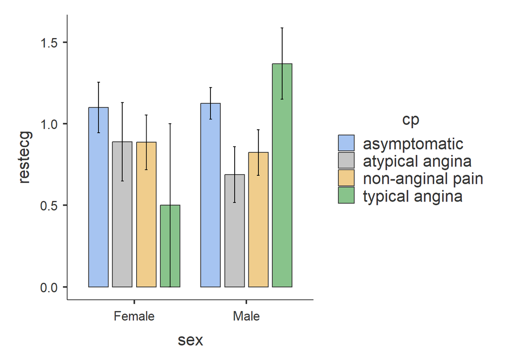

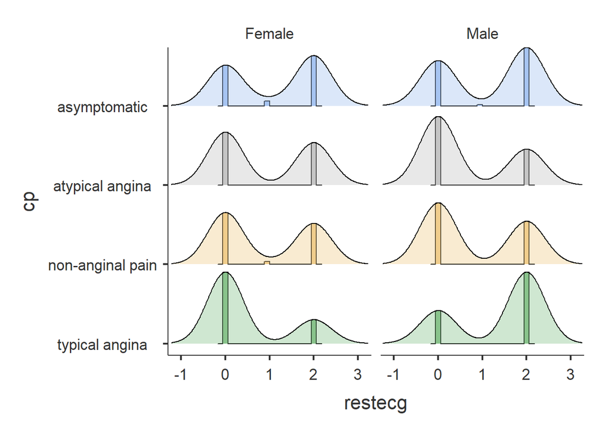

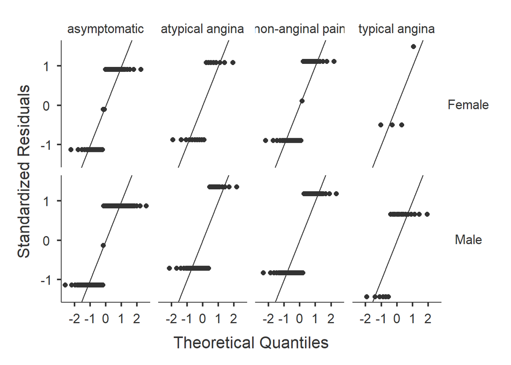

```
##
##  DESCRIPTIVES
##
##  Descriptives
##  ──────────────────────────────────────────────────────────────
##                           sex       cp                  exang
##  ──────────────────────────────────────────────────────────────
##    N                      Female    asymptomatic           40
##                                     atypical angina        18
##                                     non-anginal pain       35
##                                     typical angina          4
##                           Male      asymptomatic          104
##                                     atypical angina        32
##                                     non-anginal pain       51
##                                     typical angina         19
##    Mean                   Female    asymptomatic
##                                     atypical angina
##                                     non-anginal pain
##                                     typical angina
##                           Male      asymptomatic
##                                     atypical angina
##                                     non-anginal pain
##                                     typical angina
##    Median                 Female    asymptomatic
##                                     atypical angina
##                                     non-anginal pain
##                                     typical angina
##                           Male      asymptomatic
##                                     atypical angina
##                                     non-anginal pain
##                                     typical angina
##    Mode                   Female    asymptomatic
##                                     atypical angina
##                                     non-anginal pain
##                                     typical angina
##                           Male      asymptomatic
##                                     atypical angina
##                                     non-anginal pain
##                                     typical angina
##    Standard deviation     Female    asymptomatic
```

[output cut: 49 more lines]

```
##                                     non-anginal pain
##                                     typical angina
##                           Male      asymptomatic
##                                     atypical angina
##                                     non-anginal pain
##                                     typical angina
##    Std. error kurtosis    Female    asymptomatic
##                                     atypical angina
##                                     non-anginal pain
##                                     typical angina
##                           Male      asymptomatic
##                                     atypical angina
##                                     non-anginal pain
##                                     typical angina
##  ──────────────────────────────────────────────────────────────
```

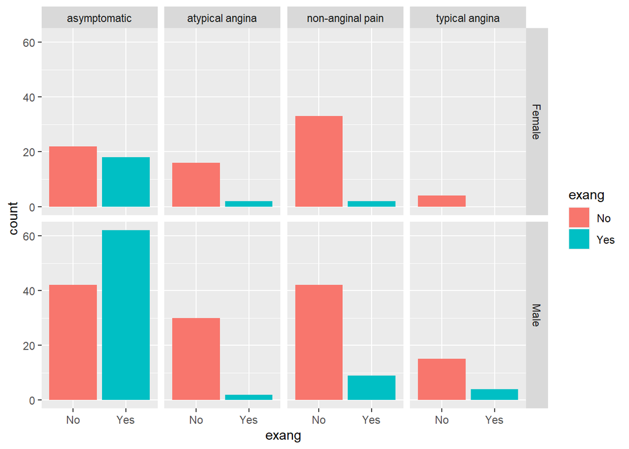

```
##
##  DESCRIPTIVES
##
##  Descriptives
##  ────────────────────────────────────────────────────────────────────
##                           sex       cp                  slope
##  ────────────────────────────────────────────────────────────────────
##    N                      Female    asymptomatic                 40
##                                     atypical angina              18
##                                     non-anginal pain             35
##                                     typical angina                4
##                           Male      asymptomatic                104
##                                     atypical angina              32
##                                     non-anginal pain             51
##                                     typical angina               19
##    Mean                   Female    asymptomatic           1.800000
##                                     atypical angina        1.333333
##                                     non-anginal pain       1.428571
##                                     typical angina         1.500000
##                           Male      asymptomatic           1.711538
##                                     atypical angina        1.312500
##                                     non-anginal pain       1.549020
##                                     typical angina         1.789474
##    Median                 Female    asymptomatic           2.000000
##                                     atypical angina        1.000000
##                                     non-anginal pain              1
##                                     typical angina         1.000000
##                           Male      asymptomatic           2.000000
##                                     atypical angina        1.000000
##                                     non-anginal pain              1
##                                     typical angina                2
##    Mode                   Female    asymptomatic           2.000000
##                                     atypical angina        1.000000
##                                     non-anginal pain       1.000000
##                                     typical angina         1.000000
##                           Male      asymptomatic           2.000000
##                                     atypical angina        1.000000
##                                     non-anginal pain       1.000000
##                                     typical angina         2.000000
##    Standard deviation     Female    asymptomatic          0.5638694
```

[output cut: 49 more lines]

```
##                                     non-anginal pain     -0.3101634
##                                     typical angina         4.000000
##                           Male      asymptomatic         -0.5695658
##                                     atypical angina        2.345538
##                                     non-anginal pain     -0.4049172
##                                     typical angina       -0.3110752
##    Std. error kurtosis    Female    asymptomatic          0.7326003
##                                     atypical angina        1.037795
##                                     non-anginal pain      0.7777944
##                                     typical angina         2.618615
##                           Male      asymptomatic          0.4694546
##                                     atypical angina       0.8093713
##                                     non-anginal pain      0.6559204
##                                     typical angina         1.014270
##  ────────────────────────────────────────────────────────────────────
```

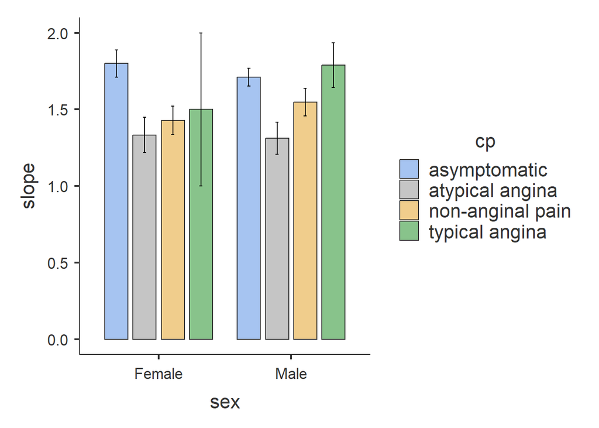

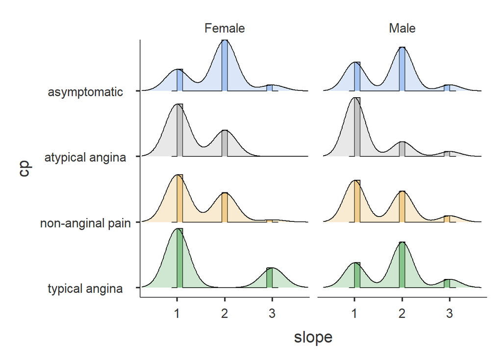

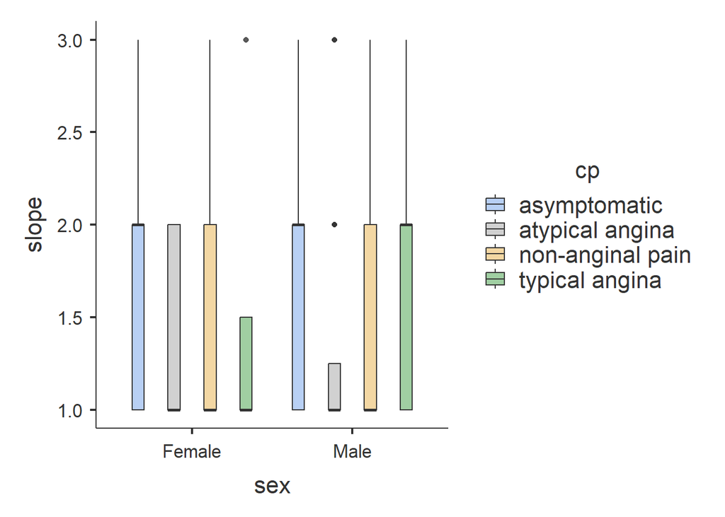

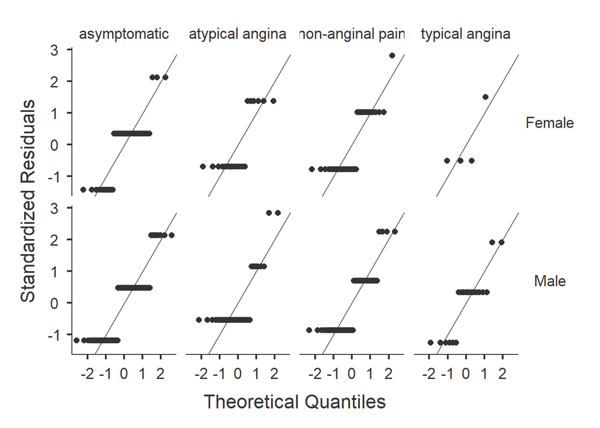

```
##
##  DESCRIPTIVES
##
##  Descriptives
##  ──────────────────────────────────────────
##         sex       cp                  ca
##  ──────────────────────────────────────────
##    N    Female    asymptomatic         40
##                   atypical angina      18
##                   non-anginal pain     35
##                   typical angina        4
##         Male      asymptomatic        104
##                   atypical angina      32
##                   non-anginal pain     51
##                   typical angina       19
##  ──────────────────────────────────────────
```

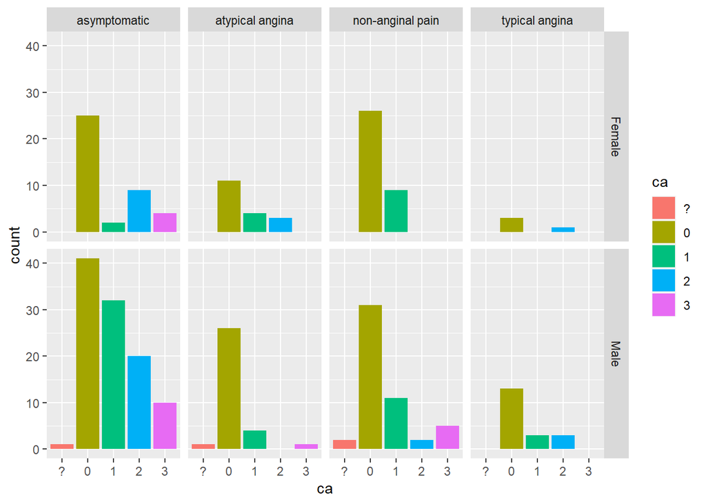

```
##
##  DESCRIPTIVES
##
##  Descriptives
##  ───────────────────────────────────────
##         cp                  num    sex
##  ───────────────────────────────────────
##    N    asymptomatic        0       39
##                             1       35
##                             2       30
##                             3       29
##                             4       11
##         atypical angina     0       41
##                             1        6
##                             2        1
##                             3        2
##                             4        0
##         non-anginal pain    0       68
##                             1        9
##                             2        4
##                             3        4
##                             4        1
##         typical angina      0       16
##                             1        5
##                             2        1
##                             3        0
##                             4        1
##  ───────────────────────────────────────
```

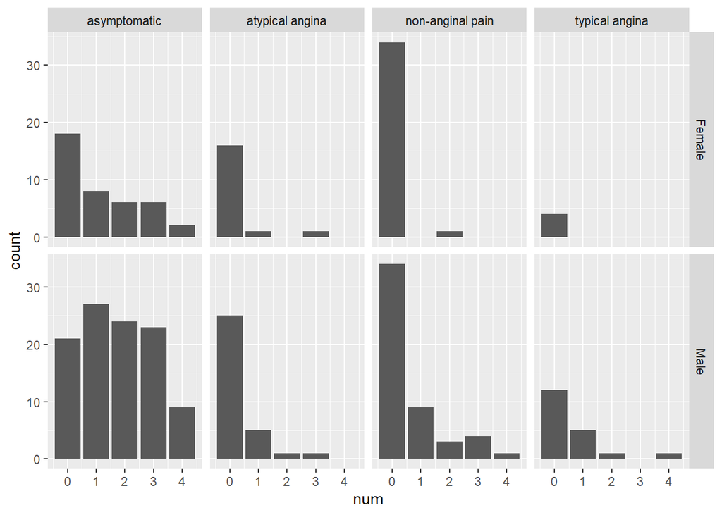

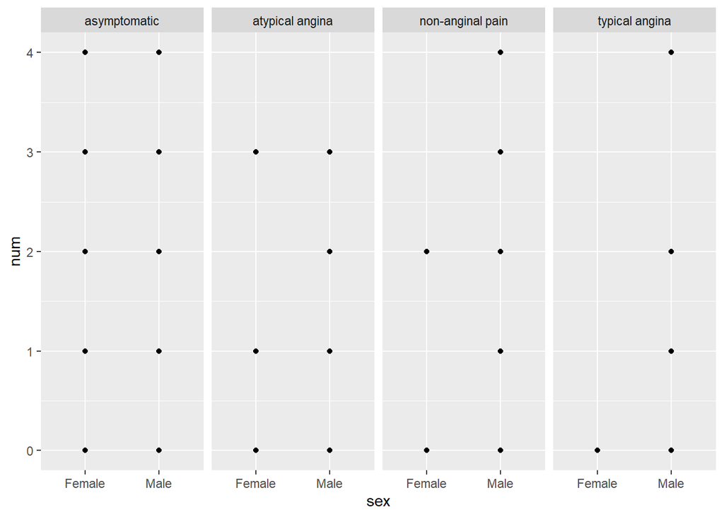

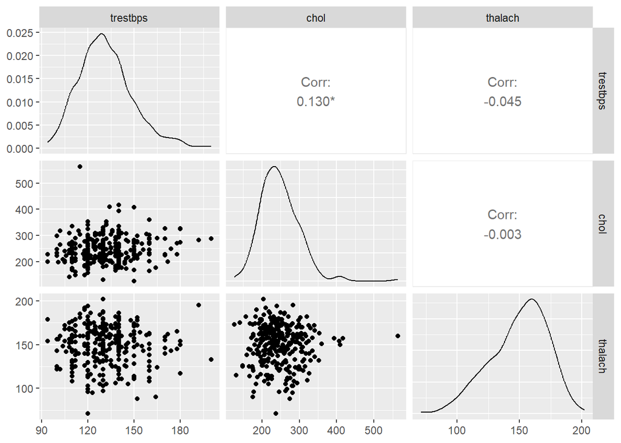

Utilizamos la funcion ggpairs para buscar si habia alguna correlacion entre las diferentes variables numericas mas no encontramos ninguna a pesar de nuestras previas asumpciones de que entre mas alto el colesterol asi seria la presion arterial o entre mas alto el ritmo cardiaco mas alto la presion arterial estas ideas fueron desmentidas por los graficos ya presentados demonstrando efectivamente una carencia de correlacion entre las variables.

## Bibliografía

Detrano, R.; Janosi, A.; Pfisterer, M.; Steinbrunn, W. (30 de junio, 1988). Heart Disease [Dataset]. https://archive.ics.uci.edu/dataset/45/heart+disease